# Binary Classification Model for Truck APS Failure Using Scikit-Learn Take 1

### July 23, 2020

Template Credit: Adapted from a template made available by Dr. Jason Brownlee of Machine Learning Mastery. [https://machinelearningmastery.com/]

SUMMARY: The purpose of this project is to construct a predictive model using various machine learning algorithms and to document the end-to-end steps using a template. The Truck APS Failure dataset is a binary classification situation where we are trying to predict one of the two possible outcomes.

INTRODUCTION: The dataset consists of data collected from heavy Scania trucks in everyday usage. The system in focus is the Air Pressure system (APS), which generates pressurized air that supports functions such as braking and gear changes. The dataset’s positive class consists of component failures for a specific component of the APS system. The negative class consists of trucks with failures for components not related to the APS. The training set contains 60000 examples in total, in which 59000 belong to the negative class and 1000 positive class. The test set contains 16000 examples.

The challenge is to minimize the total cost of a prediction model the sum of “Cost_1” multiplied by the number of Instances with type 1 failure and "Cost_2" with the number of instances with type 2 failure. The “Cost_1” variable refers to the cost resulted from a redundant check by a mechanic at the workshop. Meanwhile, the “Cost_2” variable refers to the cost of not catching a faulty truck. The cost of Type I error (cost_1) is 10, while the cost of the Type II error (cost_2) is 500.

In this Take1 iteration, we will construct and tune machine learning models for this dataset using the Scikit-Learn library. We will observe the best sensitivity/recall score that we can obtain using the tuned models with the training and test datasets.

ANALYSIS: From this Take1 iteration, the performance of the machine learning algorithms achieved an average recall metric of 59.26%. Two algorithms (Extra Trees and Random Forest) produced the top results after the first round of modeling. After a series of tuning trials, the Random Forest model completed the training phase and achieved a score of 68.53%. When configured with the optimized learning parameters, the Random Forest model processed the validation dataset with a score of 66.40%. Furthermore, the optimized model processed the test dataset with a score of 71.73% with a high Type II error rate.

CONCLUSION: For this iteration, the Random Forest model achieved the best overall results using the training and test datasets. For this dataset, we should consider using the Random Forest algorithm for further modeling and testing activities.

Dataset Used: APS Failure at Scania Trucks Data Set

Dataset ML Model: Binary classification with numerical attributes

Dataset Reference: https://archive.ics.uci.edu/ml/datasets/APS+Failure+at+Scania+Trucks

One potential source of performance benchmark: https://archive.ics.uci.edu/ml/datasets/APS+Failure+at+Scania+Trucks

Any predictive modeling machine learning project generally can be broken down into about six major tasks:

1. Prepare Environment
2. Summarize and Visualize Data
3. Pre-process Data
4. Train and Evaluate Models
5. Fine-tune and Improve Models
6. Finalize Model and Present Analysis

## Task 1 - Prepare Environment

```python
# Install the necessary packages for Colab
# !pip install python-dotenv PyMySQL
```

```python
# Retrieve the GPU information from Colab
# gpu_info = !nvidia-smi
# gpu_info = '\n'.join(gpu_info)
# if gpu_info.find('failed') >= 0:
#     print('Select the Runtime → "Change runtime type" menu to enable a GPU accelerator, ')
#     print('and then re-execute this cell.')
# else:
#     print(gpu_info)
```

```python
# Retrieve the memory configuration from Colab
# from psutil import virtual_memory
# ram_gb = virtual_memory().total / 1e9
# print('Your runtime has {:.1f} gigabytes of available RAM\n'.format(ram_gb))

# if ram_gb < 20:
#     print('To enable a high-RAM runtime, select the Runtime → "Change runtime type"')
#     print('menu, and then select High-RAM in the Runtime shape dropdown. Then, ')
#     print('re-execute this cell.')
# else:
#     print('You are using a high-RAM runtime!')
```

```python
# Retrieve the CPU information
ncpu = !nproc
print("The number of available CPUs is:", ncpu[0])
```

```
The number of available CPUs is: 4
```

### 1.a) Load libraries and modules

```python
# Set the random seed number for reproducible results
seedNum = 888
```

```python
import numpy as np
import pandas as pd
import matplotlib.pyplot as plt
import os
import sys
import math
import smtplib
import boto3
from datetime import datetime
from dotenv import load_dotenv
from sklearn import preprocessing
from sklearn.model_selection import train_test_split
# from sklearn.model_selection import KFold
from sklearn.model_selection import StratifiedKFold
from sklearn.model_selection import cross_val_score
from sklearn.model_selection import GridSearchCV
from sklearn.metrics import classification_report
from sklearn.metrics import confusion_matrix
from sklearn.metrics import accuracy_score
from sklearn.metrics import roc_auc_score
from sklearn.metrics import recall_score
from sklearn.metrics import fbeta_score
from sklearn.metrics import make_scorer
# from sklearn.pipeline import Pipeline
# from sklearn.feature_selection import RFE
# from imblearn.pipeline import Pipeline
# from imblearn.over_sampling import SMOTE
# from imblearn.under_sampling import RandomUnderSampler
# from imblearn.combine import SMOTEENN
# from imblearn.combine import SMOTETomek

from sklearn.linear_model import LogisticRegression
from sklearn.tree import DecisionTreeClassifier
from sklearn.neighbors import KNeighborsClassifier
from sklearn.ensemble import BaggingClassifier
from sklearn.ensemble import RandomForestClassifier
from sklearn.ensemble import ExtraTreesClassifier
# from imblearn.ensemble import BalancedRandomForestClassifier
# from imblearn.ensemble import RUSBoostClassifier
# from imblearn.ensemble import BalancedBaggingClassifier
# from xgboost import XGBClassifier
```

### 1.b) Set up the controlling parameters and functions

```python
# Begin the timer for the script processing
startTimeScript = datetime.now()

# Set up the number of CPU cores available for multi-thread processing
n_jobs = 2

# Set up the flag to stop sending progress emails (setting to True will send status emails!)
notifyStatus = False

# Set up the parent directory location for loading the dotenv files
useColab = False
if useColab:
    # Mount Google Drive locally for storing files
    from google.colab import drive
    drive.mount('/content/gdrive')
    gdrivePrefix = '/content/gdrive/My Drive/Colab_Downloads/'
    env_path = '/content/gdrive/My Drive/Colab Notebooks/'
    dotenv_path = env_path + "python_script.env"
    load_dotenv(dotenv_path=dotenv_path)

# Set up the dotenv file for retrieving environment variables
useLocalPC = False
if useLocalPC:
    env_path = "/Users/david/PycharmProjects/"
    dotenv_path = env_path + "python_script.env"
    load_dotenv(dotenv_path=dotenv_path)

# Configure the plotting style
plt.style.use('seaborn')

# Set Pandas options
pd.set_option("display.max_rows", None)
pd.set_option("display.width", 140)

# Set the percentage sizes for splitting the dataset
test_set_size = 0.2
val_set_size = 0.25

# Set the number of folds for cross validation
n_folds = 5

# Set metrics
scoring = 'recall'
cost_1 = 10
cost_2 = 500
beta_ratio = cost_2/cost_1
# scoring = make_scorer(fbeta_score, beta=beta_ratio)
```

```python
# Set up the email notification function
def status_notify(msg_text):
    access_key = os.environ.get('SNS_ACCESS_KEY')
    secret_key = os.environ.get('SNS_SECRET_KEY')
    aws_region = os.environ.get('SNS_AWS_REGION')
    topic_arn = "arn:aws:sns:us-east-1:072417399597:PythonMLScriptNotification"
    if (access_key is None) or (secret_key is None) or (aws_region is None):
        sys.exit("Incomplete notification setup info. Script Processing Aborted!!!")
    sns = boto3.client('sns', aws_access_key_id=access_key, aws_secret_access_key=secret_key, region_name=aws_region)
    response = sns.publish(TopicArn=topic_arn, Message=msg_text)
    if response['ResponseMetadata']['HTTPStatusCode'] != 200 :
        print('Status notification not OK with HTTP status code:', response['ResponseMetadata']['HTTPStatusCode'])
```

```python
if notifyStatus: status_notify("Task 1 - Prepare Environment has begun! " + datetime.now().strftime('%a %B %d, %Y %I:%M:%S %p'))
```

### 1.c) Load training dataset

```python
dataset_path = 'https://dainesanalytics.com/datasets/ucirvine-truck-aps-failure/aps_failure_training_set.csv'
Xy_original = pd.read_csv(dataset_path, sep=',', na_values="na", skiprows=19)

# Take a peek at the dataframe after import
Xy_original.head()
```

|  | class | aa_000 | ab_000 | ac_000 | ad_000 | ae_000 | af_000 | ag_000 | ag_001 | ag_002 | ... | ee_002 | ee_003 | ee_004 | ee_005 | ee_006 | ee_007 | ee_008 | ee_009 | ef_000 | eg_000 |
| --- | --- | --- | --- | --- | --- | --- | --- | --- | --- | --- | --- | --- | --- | --- | --- | --- | --- | --- | --- | --- | --- |
| 0 | neg | 76698 | NaN | 2.130706e+09 | 280.0 | 0.0 | 0.0 | 0.0 | 0.0 | 0.0 | ... | 1240520.0 | 493384.0 | 721044.0 | 469792.0 | 339156.0 | 157956.0 | 73224.0 | 0.0 | 0.0 | 0.0 |
| 1 | neg | 33058 | NaN | 0.000000e+00 | NaN | 0.0 | 0.0 | 0.0 | 0.0 | 0.0 | ... | 421400.0 | 178064.0 | 293306.0 | 245416.0 | 133654.0 | 81140.0 | 97576.0 | 1500.0 | 0.0 | 0.0 |
| 2 | neg | 41040 | NaN | 2.280000e+02 | 100.0 | 0.0 | 0.0 | 0.0 | 0.0 | 0.0 | ... | 277378.0 | 159812.0 | 423992.0 | 409564.0 | 320746.0 | 158022.0 | 95128.0 | 514.0 | 0.0 | 0.0 |
| 3 | neg | 12 | 0.0 | 7.000000e+01 | 66.0 | 0.0 | 10.0 | 0.0 | 0.0 | 0.0 | ... | 240.0 | 46.0 | 58.0 | 44.0 | 10.0 | 0.0 | 0.0 | 0.0 | 4.0 | 32.0 |
| 4 | neg | 60874 | NaN | 1.368000e+03 | 458.0 | 0.0 | 0.0 | 0.0 | 0.0 | 0.0 | ... | 622012.0 | 229790.0 | 405298.0 | 347188.0 | 286954.0 | 311560.0 | 433954.0 | 1218.0 | 0.0 | 0.0 |

5 rows × 171 columns

```python
Xy_original.info(verbose=True)
```

```
<class 'pandas.core.frame.DataFrame'>
RangeIndex: 60000 entries, 0 to 59999
Data columns (total 171 columns):
 #   Column  Dtype
---  ------  -----
 0   class   object
 1   aa_000  int64
 2   ab_000  float64
 3   ac_000  float64
 4   ad_000  float64
 5   ae_000  float64
 6   af_000  float64
 7   ag_000  float64
 8   ag_001  float64
 9   ag_002  float64
```

[output cut: 163 more lines]

```python
Xy_original.isnull().sum()
```

```
class         0
aa_000        0
ab_000    46329
ac_000     3335
ad_000    14861
ae_000     2500
af_000     2500
ag_000      671
ag_001      671
ag_002      671
ag_003      671
ag_004      671
ag_005      671
ag_006      671
ag_007      671
ag_008      671
ag_009      671
ah_000      645
ai_000      629
aj_000      629
ak_000     4400
al_000      642
am_0        629
an_000      642
ao_000      589
ap_000      642
aq_000      589
ar_000     2723
as_000      629
at_000      629
au_000      629
av_000     2500
ax_000     2501
ay_000      671
ay_001      671
ay_002      671
ay_003      671
ay_004      671
ay_005      671
ay_006      671
```

[output cut: 117 more lines]

```
ec_00     10239
ed_000     9553
ee_000      671
ee_001      671
ee_002      671
ee_003      671
ee_004      671
ee_005      671
ee_006      671
ee_007      671
ee_008      671
ee_009      671
ef_000     2724
eg_000     2723
dtype: int64
```

```python
print('Total number of NaN in the dataframe: ', Xy_original.isnull().sum().sum())
```

```
Total number of NaN in the dataframe:  850015
```

### 1.d) Data Cleaning

```python
# Impute missing values
Xy_original.fillna(-99999.0, inplace=True)

# Convert columns from one data type to another
Xy_original['aa_000'] = Xy_original['aa_000'].astype('float')

# Convert class variable with pos/neg levels into categorical feature of 0/1
def reclass_somecol(target):
    if target == 'pos': return 1
    else: return 0
Xy_original['targetVar'] = Xy_original['class'].apply(reclass_somecol)
Xy_original.drop(columns=['class'], inplace=True)

# Take a peek at the dataframe after cleaning
Xy_original.head()
```

|  | aa_000 | ab_000 | ac_000 | ad_000 | ae_000 | af_000 | ag_000 | ag_001 | ag_002 | ag_003 | ... | ee_003 | ee_004 | ee_005 | ee_006 | ee_007 | ee_008 | ee_009 | ef_000 | eg_000 | targetVar |
| --- | --- | --- | --- | --- | --- | --- | --- | --- | --- | --- | --- | --- | --- | --- | --- | --- | --- | --- | --- | --- | --- |
| 0 | 76698.0 | -99999.0 | 2.130706e+09 | 280.0 | 0.0 | 0.0 | 0.0 | 0.0 | 0.0 | 0.0 | ... | 493384.0 | 721044.0 | 469792.0 | 339156.0 | 157956.0 | 73224.0 | 0.0 | 0.0 | 0.0 | 0 |
| 1 | 33058.0 | -99999.0 | 0.000000e+00 | -99999.0 | 0.0 | 0.0 | 0.0 | 0.0 | 0.0 | 0.0 | ... | 178064.0 | 293306.0 | 245416.0 | 133654.0 | 81140.0 | 97576.0 | 1500.0 | 0.0 | 0.0 | 0 |
| 2 | 41040.0 | -99999.0 | 2.280000e+02 | 100.0 | 0.0 | 0.0 | 0.0 | 0.0 | 0.0 | 0.0 | ... | 159812.0 | 423992.0 | 409564.0 | 320746.0 | 158022.0 | 95128.0 | 514.0 | 0.0 | 0.0 | 0 |
| 3 | 12.0 | 0.0 | 7.000000e+01 | 66.0 | 0.0 | 10.0 | 0.0 | 0.0 | 0.0 | 318.0 | ... | 46.0 | 58.0 | 44.0 | 10.0 | 0.0 | 0.0 | 0.0 | 4.0 | 32.0 | 0 |
| 4 | 60874.0 | -99999.0 | 1.368000e+03 | 458.0 | 0.0 | 0.0 | 0.0 | 0.0 | 0.0 | 0.0 | ... | 229790.0 | 405298.0 | 347188.0 | 286954.0 | 311560.0 | 433954.0 | 1218.0 | 0.0 | 0.0 | 0 |

5 rows × 171 columns

```python
Xy_original.info(verbose=True)
```

```
<class 'pandas.core.frame.DataFrame'>
RangeIndex: 60000 entries, 0 to 59999
Data columns (total 171 columns):
 #   Column     Dtype
---  ------     -----
 0   aa_000     float64
 1   ab_000     float64
 2   ac_000     float64
 3   ad_000     float64
 4   ae_000     float64
 5   af_000     float64
 6   ag_000     float64
 7   ag_001     float64
 8   ag_002     float64
 9   ag_003     float64
```

[output cut: 163 more lines]

```python
print(Xy_original.describe())
```

```
             aa_000        ab_000        ac_000        ad_000        ae_000        af_000        ag_000        ag_001        ag_002  \
count  6.000000e+04  60000.000000  6.000000e+04  6.000000e+04  60000.000000  60000.000000  6.000000e+04  6.000000e+04  6.000000e+04
mean   5.933650e+04 -77214.065350  3.362202e+08  1.186390e+05  -4160.090000  -4156.076800 -8.991644e+02 -1.535117e+02  7.391448e+03
std    1.454301e+05  41944.761395  7.767650e+08  3.504538e+07  19984.586411  19985.852763  2.292925e+04  3.562788e+04  1.499148e+05
min    0.000000e+00 -99999.000000 -9.999900e+04 -9.999900e+04 -99999.000000 -99999.000000 -9.999900e+04 -9.999900e+04 -9.999900e+04
25%    8.340000e+02 -99999.000000  8.000000e+00  0.000000e+00      0.000000      0.000000  0.000000e+00  0.000000e+00  0.000000e+00
50%    3.077600e+04 -99999.000000  1.200000e+02  4.200000e+01      0.000000      0.000000  0.000000e+00  0.000000e+00  0.000000e+00
75%    4.866800e+04 -99999.000000  8.480000e+02  2.920000e+02      0.000000      0.000000  0.000000e+00  0.000000e+00  0.000000e+00
max    2.746564e+06    204.000000  2.130707e+09  8.584298e+09  21050.000000  20070.000000  3.376892e+06  4.109372e+06  1.055286e+07

             ag_003  ...        ee_003        ee_004        ee_005        ee_006        ee_007        ee_008        ee_009        ef_000  \
count  6.000000e+04  ...  6.000000e+04  6.000000e+04  6.000000e+04  6.000000e+04  6.000000e+04  6.000000e+04  6.000000e+04  60000.000000
mean   8.648221e+04  ...  2.076470e+05  4.396312e+05  3.884222e+05  3.282152e+05  3.412806e+05  1.360602e+05  7.176776e+03  -4539.868133
std    7.577194e+05  ...  5.412619e+05  1.163179e+06  1.115968e+06  1.064139e+06  1.719007e+06  4.476939e+05  4.856083e+04  20817.967209
min   -9.999900e+04  ... -9.999900e+04 -9.999900e+04 -9.999900e+04 -9.999900e+04 -9.999900e+04 -9.999900e+04 -9.999900e+04 -99999.000000
25%    0.000000e+00  ...  1.024000e+03  2.288000e+03  2.897000e+03  3.960000e+02  8.800000e+01  0.000000e+00  0.000000e+00      0.000000
50%    0.000000e+00  ...  1.088190e+05  2.153240e+05  1.838280e+05  8.491400e+04  3.840600e+04  3.276000e+03  0.000000e+00      0.000000
75%    0.000000e+00  ...  2.164440e+05  4.624655e+05  4.003010e+05  2.725220e+05  1.663465e+05  1.367255e+05  1.934000e+03      0.000000
max    6.340207e+07  ...  3.775839e+07  9.715238e+07  5.743524e+07  3.160781e+07  1.195801e+08  1.926740e+07  3.810078e+06    482.000000

             eg_000     targetVar
count  60000.000000  60000.000000
mean   -4538.084850      0.016667
std    20814.354127      0.128020
min   -99999.000000      0.000000
25%        0.000000      0.000000
50%        0.000000      0.000000
75%        0.000000      0.000000
max     1146.000000      1.000000

[8 rows x 171 columns]
```

```python
Xy_original.isnull().sum()
```

```
aa_000       0
ab_000       0
ac_000       0
ad_000       0
ae_000       0
af_000       0
ag_000       0
ag_001       0
ag_002       0
ag_003       0
ag_004       0
ag_005       0
ag_006       0
ag_007       0
ag_008       0
ag_009       0
ah_000       0
ai_000       0
aj_000       0
ak_000       0
al_000       0
am_0         0
an_000       0
ao_000       0
ap_000       0
aq_000       0
ar_000       0
as_000       0
at_000       0
au_000       0
av_000       0
ax_000       0
ay_000       0
ay_001       0
ay_002       0
ay_003       0
ay_004       0
ay_005       0
ay_006       0
ay_007       0
```

[output cut: 117 more lines]

```
ed_000       0
ee_000       0
ee_001       0
ee_002       0
ee_003       0
ee_004       0
ee_005       0
ee_006       0
ee_007       0
ee_008       0
ee_009       0
ef_000       0
eg_000       0
targetVar    0
dtype: int64
```

```python
print('Total number of NaN in the dataframe: ', Xy_original.isnull().sum().sum())
```

```
Total number of NaN in the dataframe:  0
```

### 1.e) Splitting Data into Attribute-only and Target-only Sets

```python
# Use variable totCol to hold the number of columns in the dataframe
totCol = len(Xy_original.columns)

# Set up variable totAttr for the total number of attribute columns
totAttr = totCol-1

# targetCol variable indicates the column location of the target/class variable
# If the first column, set targetCol to 1. If the last column, set targetCol to totCol
# If (targetCol <> 1) and (targetCol <> totCol), be aware when slicing up the dataframes for visualization
targetCol = totCol
```

```python
# We create attribute-only and target-only datasets (X_original and y_original)
# for various visualization and cleaning/transformation operations

if targetCol == totCol:
    X_original = Xy_original.iloc[:,0:totAttr]
    y_original = Xy_original.iloc[:,totAttr]
else:
    X_original = Xy_original.iloc[:,1:totCol]
    y_original = Xy_original.iloc[:,0]

print("Xy_original.shape: {} X_original.shape: {} y_original.shape: {}".format(Xy_original.shape, X_original.shape, y_original.shape))
```

```
Xy_original.shape: (60000, 171) X_original.shape: (60000, 170) y_original.shape: (60000,)
```

### 1.f) Set up the parameters for data visualization

```python
# Set up the number of row and columns for visualization display. dispRow * dispCol should be >= totAttr
dispCol = 4
if totAttr % dispCol == 0 :
    dispRow = totAttr // dispCol
else :
    dispRow = (totAttr // dispCol) + 1

# Set figure width to display the data visualization plots
fig_size = plt.rcParams["figure.figsize"]
fig_size[0] = dispCol*4
fig_size[1] = dispRow*4
plt.rcParams["figure.figsize"] = fig_size
```

```python
if notifyStatus: status_notify("Task 1 - Prepare Environment completed! "+datetime.now().strftime('%a %B %d, %Y %I:%M:%S %p'))
```

## Task 2 - Summarize and Visualize Data

```python
if notifyStatus: status_notify("Task 2 - Summarize and Visualize Data has begun! "+datetime.now().strftime('%a %B %d, %Y %I:%M:%S %p'))
```

### 2.a) Descriptive Statistics

#### 2.a.i) Peek at the attribute columns

```python
X_original.head()
```

|  | aa_000 | ab_000 | ac_000 | ad_000 | ae_000 | af_000 | ag_000 | ag_001 | ag_002 | ag_003 | ... | ee_002 | ee_003 | ee_004 | ee_005 | ee_006 | ee_007 | ee_008 | ee_009 | ef_000 | eg_000 |
| --- | --- | --- | --- | --- | --- | --- | --- | --- | --- | --- | --- | --- | --- | --- | --- | --- | --- | --- | --- | --- | --- |
| 0 | 76698.0 | -99999.0 | 2.130706e+09 | 280.0 | 0.0 | 0.0 | 0.0 | 0.0 | 0.0 | 0.0 | ... | 1240520.0 | 493384.0 | 721044.0 | 469792.0 | 339156.0 | 157956.0 | 73224.0 | 0.0 | 0.0 | 0.0 |
| 1 | 33058.0 | -99999.0 | 0.000000e+00 | -99999.0 | 0.0 | 0.0 | 0.0 | 0.0 | 0.0 | 0.0 | ... | 421400.0 | 178064.0 | 293306.0 | 245416.0 | 133654.0 | 81140.0 | 97576.0 | 1500.0 | 0.0 | 0.0 |
| 2 | 41040.0 | -99999.0 | 2.280000e+02 | 100.0 | 0.0 | 0.0 | 0.0 | 0.0 | 0.0 | 0.0 | ... | 277378.0 | 159812.0 | 423992.0 | 409564.0 | 320746.0 | 158022.0 | 95128.0 | 514.0 | 0.0 | 0.0 |
| 3 | 12.0 | 0.0 | 7.000000e+01 | 66.0 | 0.0 | 10.0 | 0.0 | 0.0 | 0.0 | 318.0 | ... | 240.0 | 46.0 | 58.0 | 44.0 | 10.0 | 0.0 | 0.0 | 0.0 | 4.0 | 32.0 |
| 4 | 60874.0 | -99999.0 | 1.368000e+03 | 458.0 | 0.0 | 0.0 | 0.0 | 0.0 | 0.0 | 0.0 | ... | 622012.0 | 229790.0 | 405298.0 | 347188.0 | 286954.0 | 311560.0 | 433954.0 | 1218.0 | 0.0 | 0.0 |

5 rows × 170 columns

#### 2.a.ii) Dimensions and attribute types

```python
X_original.info(verbose=True)
```

```
<class 'pandas.core.frame.DataFrame'>
RangeIndex: 60000 entries, 0 to 59999
Data columns (total 170 columns):
 #   Column  Dtype
---  ------  -----
 0   aa_000  float64
 1   ab_000  float64
 2   ac_000  float64
 3   ad_000  float64
 4   ae_000  float64
 5   af_000  float64
 6   ag_000  float64
 7   ag_001  float64
 8   ag_002  float64
 9   ag_003  float64
```

[output cut: 162 more lines]

#### 2.a.iii) Statistical summary of the attributes

```python
print(X_original.describe())
```

```
             aa_000        ab_000        ac_000        ad_000        ae_000        af_000        ag_000        ag_001        ag_002  \
count  6.000000e+04  60000.000000  6.000000e+04  6.000000e+04  60000.000000  60000.000000  6.000000e+04  6.000000e+04  6.000000e+04
mean   5.933650e+04 -77214.065350  3.362202e+08  1.186390e+05  -4160.090000  -4156.076800 -8.991644e+02 -1.535117e+02  7.391448e+03
std    1.454301e+05  41944.761395  7.767650e+08  3.504538e+07  19984.586411  19985.852763  2.292925e+04  3.562788e+04  1.499148e+05
min    0.000000e+00 -99999.000000 -9.999900e+04 -9.999900e+04 -99999.000000 -99999.000000 -9.999900e+04 -9.999900e+04 -9.999900e+04
25%    8.340000e+02 -99999.000000  8.000000e+00  0.000000e+00      0.000000      0.000000  0.000000e+00  0.000000e+00  0.000000e+00
50%    3.077600e+04 -99999.000000  1.200000e+02  4.200000e+01      0.000000      0.000000  0.000000e+00  0.000000e+00  0.000000e+00
75%    4.866800e+04 -99999.000000  8.480000e+02  2.920000e+02      0.000000      0.000000  0.000000e+00  0.000000e+00  0.000000e+00
max    2.746564e+06    204.000000  2.130707e+09  8.584298e+09  21050.000000  20070.000000  3.376892e+06  4.109372e+06  1.055286e+07

             ag_003  ...        ee_002        ee_003        ee_004        ee_005        ee_006        ee_007        ee_008        ee_009  \
count  6.000000e+04  ...  6.000000e+04  6.000000e+04  6.000000e+04  6.000000e+04  6.000000e+04  6.000000e+04  6.000000e+04  6.000000e+04
mean   8.648221e+04  ...  4.393893e+05  2.076470e+05  4.396312e+05  3.884222e+05  3.282152e+05  3.412806e+05  1.360602e+05  7.176776e+03
std    7.577194e+05  ...  1.150491e+06  5.412619e+05  1.163179e+06  1.115968e+06  1.064139e+06  1.719007e+06  4.476939e+05  4.856083e+04
min   -9.999900e+04  ... -9.999900e+04 -9.999900e+04 -9.999900e+04 -9.999900e+04 -9.999900e+04 -9.999900e+04 -9.999900e+04 -9.999900e+04
25%    0.000000e+00  ...  2.662000e+03  1.024000e+03  2.288000e+03  2.897000e+03  3.960000e+02  8.800000e+01  0.000000e+00  0.000000e+00
50%    0.000000e+00  ...  2.280220e+05  1.088190e+05  2.153240e+05  1.838280e+05  8.491400e+04  3.840600e+04  3.276000e+03  0.000000e+00
75%    0.000000e+00  ...  4.350315e+05  2.164440e+05  4.624655e+05  4.003010e+05  2.725220e+05  1.663465e+05  1.367255e+05  1.934000e+03
max    6.340207e+07  ...  7.793393e+07  3.775839e+07  9.715238e+07  5.743524e+07  3.160781e+07  1.195801e+08  1.926740e+07  3.810078e+06

             ef_000        eg_000
count  60000.000000  60000.000000
mean   -4539.868133  -4538.084850
std    20817.967209  20814.354127
min   -99999.000000 -99999.000000
25%        0.000000      0.000000
50%        0.000000      0.000000
75%        0.000000      0.000000
max      482.000000   1146.000000

[8 rows x 170 columns]
```

#### 2.a.iv) Summarize the levels of the class attribute

```python
Xy_original.groupby('targetVar').size()
```

```
targetVar
0    59000
1     1000
dtype: int64
```

### 2.b) Data Visualization

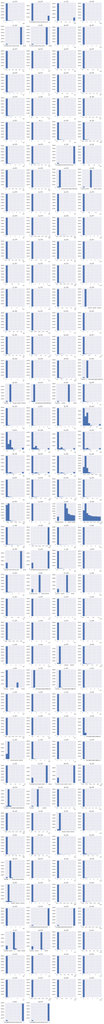

```python
# Histograms for each attribute
X_original.hist(layout=(dispRow,dispCol))
plt.show()
```

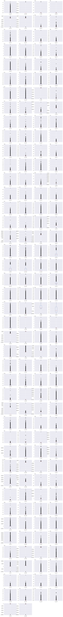

```python
# Box and Whisker plot for each attribute
X_original.plot(kind='box', subplots=True, layout=(dispRow,dispCol))
plt.show()
```

```python
# Correlation matrix
# fig = plt.figure(figsize=(16,12))
# ax = fig.add_subplot(111)
# correlations = X_original.corr(method='pearson')
# cax = ax.matshow(correlations, vmin=-1, vmax=1)
# fig.colorbar(cax)
# plt.show()
```

```python
if notifyStatus: status_notify("Task 2 - Summarize and Visualize Data completed! "+datetime.now().strftime('%a %B %d, %Y %I:%M:%S %p'))
```

## Task 3 - Pre-process Data

```python
if notifyStatus: status_notify("Task 3 - Pre-process Data has begun! "+datetime.now().strftime('%a %B %d, %Y %I:%M:%S %p'))
```

### 3.a) Splitting Data into Training and Test Sets

```python
# Not applicable for this iteration of the project
# Perform one-hot-encoding on the categorical attributes
# X_original = pd.get_dummies(X_original)
# print(X_original.info())
```

```python
# Split the data further into training and test datasets
X_train_df, X_validation_df, y_train_df, y_validation_df = train_test_split(X_original, y_original, test_size=val_set_size, stratify=y_original, random_state=seedNum)
print("X_train_df.shape: {} y_train_df.shape: {}".format(X_train_df.shape, y_train_df.shape))
print("X_validation_df.shape: {} y_validation_df.shape: {}".format(X_validation_df.shape, y_validation_df.shape))
```

```
X_train_df.shape: (45000, 170) y_train_df.shape: (45000,)
X_validation_df.shape: (15000, 170) y_validation_df.shape: (15000,)
```

### 3.b) Feature Scaling and Data Pre-Processing

```python
# Gather a list of features for applying the data pre-processing
columns_to_scale = X_train_df.columns[X_train_df.dtypes == 'float64'].tolist()
print('Columns to scale are:', columns_to_scale)
```

```
Columns to scale are: ['aa_000', 'ab_000', 'ac_000', 'ad_000', 'ae_000', 'af_000', 'ag_000', 'ag_001', 'ag_002', 'ag_003', 'ag_004', 'ag_005', 'ag_006', 'ag_007', 'ag_008', 'ag_009', 'ah_000', 'ai_000', 'aj_000', 'ak_000', 'al_000', 'am_0', 'an_000', 'ao_000', 'ap_000', 'aq_000', 'ar_000', 'as_000',…
```

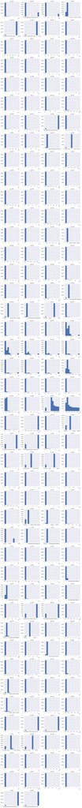

```python
# Histograms for each attribute before pre-processing
X_train_df[columns_to_scale].hist(layout=(dispRow,dispCol))
plt.show()
```

```python
# Apply feature scaling and transformation to the training dataset
scaler = preprocessing.MinMaxScaler()
X_train_df[columns_to_scale] = scaler.fit_transform(X_train_df[columns_to_scale])
print(X_train_df.head())
```

```
         aa_000    ab_000    ac_000    ad_000    ae_000    af_000    ag_000    ag_001    ag_002    ag_003  ...    ee_002    ee_003  \
53184  0.000796  0.000000  0.000047  0.140483  0.826103  0.832846  0.028761  0.023974  0.010742  0.002150  ...  0.001369  0.002748
38127  0.351795  0.997984  0.000057  0.140500  0.826103  0.832846  0.028761  0.023756  0.010820  0.055879  ...  0.045124  0.057687
23467  0.000007  0.000000  0.000047  0.140396  0.826103  0.832846  0.028761  0.023756  0.009387  0.001575  ...  0.001284  0.002643
34170  0.022194  0.000000  1.000000  0.140882  0.826103  0.832846  0.028761  0.023756  0.009387  0.001575  ...  0.007427  0.009570
55321  0.000004  0.997964  0.000047  0.140404  0.826103  0.832846  0.028761  0.023756  0.009387  0.001607  ...  0.001283  0.002642

         ee_004    ee_005    ee_006    ee_007    ee_008    ee_009    ef_000   eg_000
53184  0.001238  0.002317  0.003722  0.000951  0.005179  0.035611  0.995203  0.98867
38127  0.054903  0.017151  0.039636  0.023552  0.007982  0.035611  0.995203  0.98867
23467  0.001029  0.001740  0.003155  0.000836  0.005163  0.035611  0.995203  0.98867
34170  0.006656  0.011630  0.016908  0.002874  0.016486  0.035993  0.995203  0.98867
55321  0.001029  0.001739  0.003155  0.000836  0.005163  0.035611  0.995203  0.98867

[5 rows x 170 columns]
```

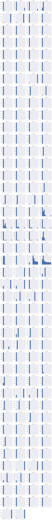

```python
# Histograms for each attribute after pre-processing
X_train_df[columns_to_scale].hist(layout=(dispRow,dispCol))
plt.show()
```

```python
# Apply feature scaling and transformation to the validation dataset
scaled_features = scaler.transform(X_validation_df[columns_to_scale])
X_validation_df.loc[:,tuple(columns_to_scale)] = scaled_features
print(X_validation_df.head())
```

```
             aa_000    ab_000    ac_000    ad_000    ae_000    af_000    ag_000    ag_001    ag_002    ag_003  ...    ee_002    ee_003  \
33395  7.092498e-04  0.000000  0.000047  0.140432  0.826103  0.832846  0.028761  0.023756  0.009387  0.001575  ...  0.001351  0.002707
24323  4.369095e-06  0.997964  0.000047  0.140404  0.826103  0.832846  0.028761  0.023756  0.009387  0.001585  ...  0.001282  0.002642
3712   7.281826e-07  0.000000  0.000047  0.140415  0.826103  0.832846  0.028761  0.023756  0.009387  0.001659  ...  0.001283  0.002643
56135  3.449182e-02  0.000000  0.000000  0.000000  0.000000  0.000000  0.028761  0.023756  0.009387  0.001575  ...  0.015870  0.019033
7328   1.126790e-02  0.000000  0.000047  0.141109  0.826103  0.832846  0.028761  0.023756  0.009387  0.001575  ...  0.004856  0.006227

         ee_004    ee_005    ee_006    ee_007    ee_008    ee_009    ef_000   eg_000
33395  0.001100  0.002902  0.003263  0.000839  0.005223  0.035615  0.995203  0.98867
24323  0.001029  0.001739  0.003157  0.000836  0.005163  0.035611  0.995203  0.98867
3712   0.001029  0.001738  0.003155  0.000836  0.005163  0.035611  0.995203  0.98867
56135  0.014485  0.015815  0.014749  0.002005  0.011139  0.035980  0.000000  0.00000
7328   0.005925  0.008604  0.006477  0.001133  0.005998  0.035883  0.995203  0.98867

[5 rows x 170 columns]
```

### 3.c) Training Data Balancing

```python
# Not applicable for this iteration of the project
```

### 3.d) Feature Selection

```python
# Not applicable for this iteration of the project
```

### 3.e) Display the Final Datasets for Model-Building

```python
# Finalize the training datasets for the modeling activities
X_train = X_train_df.to_numpy()
y_train = y_train_df.ravel()
X_validation = X_validation_df.to_numpy()
y_validation = y_validation_df.ravel()
print("X_train.shape: {} y_train.shape: {}".format(X_train.shape, y_train.shape))
print("X_validation.shape: {} y_validation.shape: {}".format(X_validation.shape, y_validation.shape))
```

```
X_train.shape: (45000, 170) y_train.shape: (45000,)
X_validation.shape: (15000, 170) y_validation.shape: (15000,)
```

```python
if notifyStatus: status_notify("Task 3 - Pre-process Data completed! "+datetime.now().strftime('%a %B %d, %Y %I:%M:%S %p'))
```

## Task 4 - Train and Evaluate Models

```python
if notifyStatus: status_notify("Task 4 - Train and Evaluate Models has begun! "+datetime.now().strftime('%a %B %d, %Y %I:%M:%S %p'))
```

### 4.a) Set test options and evaluation metric

```python
# Set up Algorithms Spot-Checking Array
startTimeTraining = datetime.now()
train_models = []
train_results = []
train_model_names = []
train_metrics = []
train_models.append(('LGR', LogisticRegression(random_state=seedNum)))
train_models.append(('CART', DecisionTreeClassifier(random_state=seedNum)))
train_models.append(('KNN', KNeighborsClassifier(n_jobs=n_jobs)))
train_models.append(('BGT', BaggingClassifier(random_state=seedNum, n_jobs=n_jobs)))
train_models.append(('RNF', RandomForestClassifier(random_state=seedNum, n_jobs=n_jobs)))
train_models.append(('EXT', ExtraTreesClassifier(random_state=seedNum, n_jobs=n_jobs)))
# train_models.append(('XGB', XGBClassifier(random_state=seedNum, n_jobs=n_jobs, tree_method='gpu_hist')))
```

```python
# Generate model in turn
for name, model in train_models:
	if notifyStatus: status_notify("Algorithm "+name+" modeling has begun! "+datetime.now().strftime('%a %B %d, %Y %I:%M:%S %p'))
	startTimeModule = datetime.now()
	kfold = StratifiedKFold(n_splits=n_folds, shuffle=True, random_state=seedNum)
	cv_results = cross_val_score(model, X_train, y_train, cv=kfold, scoring=scoring, n_jobs=n_jobs, verbose=1)
	train_results.append(cv_results)
	train_model_names.append(name)
	train_metrics.append(cv_results.mean())
	print("%s: %f (%f)" % (name, cv_results.mean(), cv_results.std()))
	print(model)
	print ('Model training time:', (datetime.now() - startTimeModule), '\n')
	if notifyStatus: status_notify("Algorithm "+name+" modeling completed! "+datetime.now().strftime('%a %B %d, %Y %I:%M:%S %p'))
print ('Average metrics ('+scoring+') from all models:',np.mean(train_metrics))
print ('Total training time for all models:',(datetime.now() - startTimeTraining))
```

```
[Parallel(n_jobs=2)]: Using backend LokyBackend with 2 concurrent workers.
[Parallel(n_jobs=2)]: Done   5 out of   5 | elapsed:    8.0s finished
[Parallel(n_jobs=2)]: Using backend LokyBackend with 2 concurrent workers.
```

```
LGR: 0.462667 (0.055554)
LogisticRegression(random_state=888)
Model training time: 0:00:07.991763
```

```
[Parallel(n_jobs=2)]: Done   5 out of   5 | elapsed:  1.2min finished
[Parallel(n_jobs=2)]: Using backend LokyBackend with 2 concurrent workers.
```

```
CART: 0.669333 (0.052085)
DecisionTreeClassifier(random_state=888)
Model training time: 0:01:09.973608
```

```
[Parallel(n_jobs=2)]: Done   5 out of   5 | elapsed:  3.0min finished
[Parallel(n_jobs=2)]: Using backend LokyBackend with 2 concurrent workers.
```

```
KNN: 0.402667 (0.023702)
KNeighborsClassifier(n_jobs=2)
Model training time: 0:02:57.648755
```

```
[Parallel(n_jobs=2)]: Done   5 out of   5 | elapsed:  3.2min finished
[Parallel(n_jobs=2)]: Using backend LokyBackend with 2 concurrent workers.
```

```
BGT: 0.662667 (0.033360)
BaggingClassifier(n_jobs=2, random_state=888)
Model training time: 0:03:13.092596
```

```
[Parallel(n_jobs=2)]: Done   5 out of   5 | elapsed:  1.9min finished
[Parallel(n_jobs=2)]: Using backend LokyBackend with 2 concurrent workers.
```

```
RNF: 0.673333 (0.022706)
RandomForestClassifier(n_jobs=2, random_state=888)
Model training time: 0:01:54.095164

EXT: 0.685333 (0.037571)
ExtraTreesClassifier(n_jobs=2, random_state=888)
Model training time: 0:00:36.205835

Average metrics (recall) from all models: 0.5926666666666668
Total training time for all models: 0:09:59.145919
```

```
[Parallel(n_jobs=2)]: Done   5 out of   5 | elapsed:   36.1s finished
```

### 4.b) Spot-checking baseline algorithms

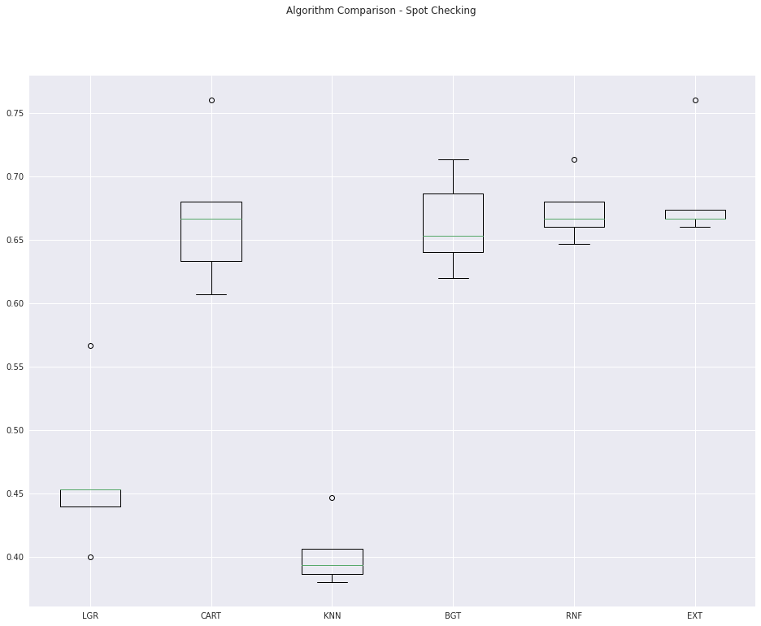

```python
fig = plt.figure(figsize=(16,12))
fig.suptitle('Algorithm Comparison - Spot Checking')
ax = fig.add_subplot(111)
plt.boxplot(train_results)
ax.set_xticklabels(train_model_names)
plt.show()
```

```python
if notifyStatus: status_notify("Task 4 - Train and Evaluate Models completed! "+datetime.now().strftime('%a %B %d, %Y %I:%M:%S %p'))
```

## Task 5 - Fine-tune and Improve Models

```python
if notifyStatus: status_notify("Task 5 - Fine-tune and Improve Models has begun! "+datetime.now().strftime('%a %B %d, %Y %I:%M:%S %p'))
```

### 5.a) Algorithm Tuning

```python
# Set up the comparison array
tune_results = []
tune_model_names = []
```

```python
# Tuning algorithm #1 - Extra Trees
startTimeModule = datetime.now()
if notifyStatus: status_notify("Algorithm #1 tuning has begun! "+datetime.now().strftime('%a %B %d, %Y %I:%M:%S %p'))

tune_model1 = ExtraTreesClassifier(random_state=seedNum, n_jobs=n_jobs)
tune_model_names.append('EXT')
paramGrid1 = dict(n_estimators=np.array([100, 200, 300, 400, 500]))

kfold = StratifiedKFold(n_splits=n_folds, shuffle=True, random_state=seedNum)
grid1 = GridSearchCV(estimator=tune_model1, param_grid=paramGrid1, scoring=scoring, cv=kfold, n_jobs=n_jobs, verbose=1)
grid_result1 = grid1.fit(X_train, y_train)

print("Best: %f using %s" % (grid_result1.best_score_, grid_result1.best_params_))
tune_results.append(grid_result1.cv_results_['mean_test_score'])
means = grid_result1.cv_results_['mean_test_score']
stds = grid_result1.cv_results_['std_test_score']
params = grid_result1.cv_results_['params']
for mean, stdev, param in zip(means, stds, params):
    print("%f (%f) with: %r" % (mean, stdev, param))
print ('Model training time:',(datetime.now() - startTimeModule))
if notifyStatus: status_notify("Algorithm #1 tuning completed! "+datetime.now().strftime('%a %B %d, %Y %I:%M:%S %p'))
```

```
Fitting 5 folds for each of 5 candidates, totalling 25 fits
```

```
[Parallel(n_jobs=2)]: Using backend LokyBackend with 2 concurrent workers.
[Parallel(n_jobs=2)]: Done  25 out of  25 | elapsed:  7.8min finished
```

```
Best: 0.692000 using {'n_estimators': 500}
0.685333 (0.037571) with: {'n_estimators': 100}
0.684000 (0.039911) with: {'n_estimators': 200}
0.692000 (0.031098) with: {'n_estimators': 300}
0.688000 (0.035125) with: {'n_estimators': 400}
0.692000 (0.033307) with: {'n_estimators': 500}
Model training time: 0:08:47.039819
```

```python
best_paramKey1 = list(grid_result1.best_params_.keys())[0]
best_paramValue1 = list(grid_result1.best_params_.values())[0]
print("Captured the best parameter for algorithm #1:", best_paramKey1, '=', best_paramValue1)
```

```
Captured the best parameter for algorithm #1: n_estimators = 500
```

```python
# Tuning algorithm #2 - Random Forest
startTimeModule = datetime.now()
if notifyStatus: status_notify("Algorithm #2 tuning has begun! "+datetime.now().strftime('%a %B %d, %Y %I:%M:%S %p'))

tune_model2 = RandomForestClassifier(random_state=seedNum, n_jobs=n_jobs)
tune_model_names.append('RNF')
paramGrid2 = dict(n_estimators=np.array([100, 200, 300, 400, 500]))

kfold = StratifiedKFold(n_splits=n_folds, shuffle=True, random_state=seedNum)
grid2 = GridSearchCV(estimator=tune_model2, param_grid=paramGrid2, scoring=scoring, cv=kfold, n_jobs=n_jobs, verbose=1)
grid_result2 = grid2.fit(X_train, y_train)

print("Best: %f using %s" % (grid_result2.best_score_, grid_result2.best_params_))
tune_results.append(grid_result2.cv_results_['mean_test_score'])
means = grid_result2.cv_results_['mean_test_score']
stds = grid_result2.cv_results_['std_test_score']
params = grid_result2.cv_results_['params']
for mean, stdev, param in zip(means, stds, params):
    print("%f (%f) with: %r" % (mean, stdev, param))
print ('Model training time:',(datetime.now() - startTimeModule))
if notifyStatus: status_notify("Algorithm #2 tuning completed! "+datetime.now().strftime('%a %B %d, %Y %I:%M:%S %p'))
```

```
Fitting 5 folds for each of 5 candidates, totalling 25 fits
```

```
[Parallel(n_jobs=2)]: Using backend LokyBackend with 2 concurrent workers.
[Parallel(n_jobs=2)]: Done  25 out of  25 | elapsed: 24.7min finished
```

```
Best: 0.685333 using {'n_estimators': 400}
0.673333 (0.022706) with: {'n_estimators': 100}
0.681333 (0.024368) with: {'n_estimators': 200}
0.685333 (0.035125) with: {'n_estimators': 300}
0.685333 (0.038964) with: {'n_estimators': 400}
0.678667 (0.040310) with: {'n_estimators': 500}
Model training time: 0:27:58.043702
```

```python
best_paramKey2 = list(grid_result2.best_params_.keys())[0]
best_paramValue2 = list(grid_result2.best_params_.values())[0]
print("Captured the best parameter for algorithm #2:", best_paramKey2, '=', best_paramValue2)
```

```
Captured the best parameter for algorithm #2: n_estimators = 400
```

### 5.b) Compare Algorithms After Tuning

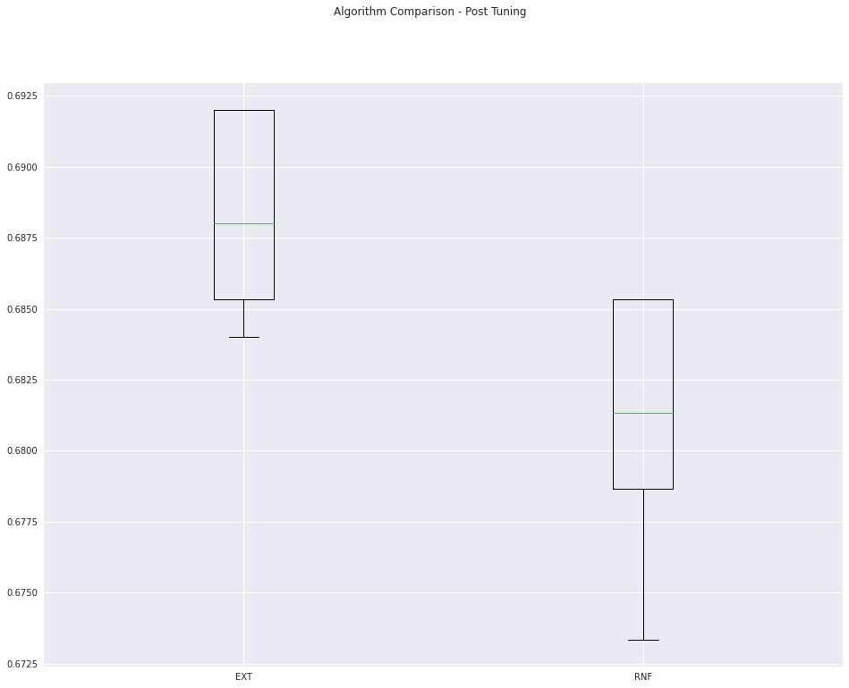

```python
fig = plt.figure(figsize=(16,12))
fig.suptitle('Algorithm Comparison - Post Tuning')
ax = fig.add_subplot(111)
plt.boxplot(tune_results)
ax.set_xticklabels(tune_model_names)
plt.show()
```

```python
if notifyStatus: status_notify("Task 5 - Fine-tune and Improve Models completed! "+datetime.now().strftime('%a %B %d, %Y %I:%M:%S %p'))
```

## Task 6 - Finalize Model and Present Analysis

```python
if notifyStatus: status_notify("Task 6 - Finalize Model and Present Analysis has begun! "+datetime.now().strftime('%a %B %d, %Y %I:%M:%S %p'))
```

### 6.a) Validate the models using the validation dataset

```python
validation_model1 = ExtraTreesClassifier(n_estimators=best_paramValue1, random_state=seedNum, n_jobs=n_jobs)
validation_model1.fit(X_train, y_train)
predictions1 = validation_model1.predict(X_validation)
print('Accuracy Score:', accuracy_score(y_validation, predictions1))
print('ROC/AUC Score:', roc_auc_score(y_validation, predictions1))
print('Recall Score:', recall_score(y_validation, predictions1))
print('F-beta Score:', fbeta_score(y_validation, predictions1, beta=beta_ratio))
cf1 = confusion_matrix(y_validation, predictions1)
print(cf1)
print('False Positive (Type 1 Error):', cf1[0,1])
print('False Negative (Type 2 Error):', cf1[1,0])
print('Total of Type I and Type II costs:', ((cost_1 * cf1[0,1]) + (cost_2 * cf1[1,0])))
print(classification_report(y_validation, predictions1))
print(validation_model1)
```

```
Accuracy Score: 0.9927333333333334
ROC/AUC Score: 0.8232881355932203
Recall Score: 0.648
F-beta Score: 0.648069445266426
[[14729    21]
 [   88   162]]
False Positive (Type 1 Error): 21
False Negative (Type 2 Error): 88
Total of Type I and Type II costs: 44210
              precision    recall  f1-score   support

           0       0.99      1.00      1.00     14750
           1       0.89      0.65      0.75       250

    accuracy                           0.99     15000
   macro avg       0.94      0.82      0.87     15000
weighted avg       0.99      0.99      0.99     15000

ExtraTreesClassifier(n_estimators=500, n_jobs=2, random_state=888)
```

```python
validation_model2 = RandomForestClassifier(n_estimators=best_paramValue2, random_state=seedNum, n_jobs=n_jobs)
validation_model2.fit(X_train, y_train)
predictions2 = validation_model2.predict(X_validation)
print('Accuracy Score:', accuracy_score(y_validation, predictions2))
print('ROC/AUC Score:', roc_auc_score(y_validation, predictions2))
print('Recall Score:', recall_score(y_validation, predictions2))
print('F-beta Score:', fbeta_score(y_validation, predictions2, beta=beta_ratio))
cf2 = confusion_matrix(y_validation, predictions2)
print(cf2)
print('False Positive (Type 1 Error):', cf2[0,1])
print('False Negative (Type 2 Error):', cf2[1,0])
print('Total of Type I and Type II costs:', ((cost_1 * cf2[0,1]) + (cost_2 * cf2[1,0])))
print(classification_report(y_validation, predictions2))
print(validation_model2)
```

```
Accuracy Score: 0.9931333333333333
ROC/AUC Score: 0.8313559322033899
Recall Score: 0.664
F-beta Score: 0.6640690355654726
[[14731    19]
 [   84   166]]
False Positive (Type 1 Error): 19
False Negative (Type 2 Error): 84
Total of Type I and Type II costs: 42190
              precision    recall  f1-score   support

           0       0.99      1.00      1.00     14750
           1       0.90      0.66      0.76       250

    accuracy                           0.99     15000
   macro avg       0.95      0.83      0.88     15000
weighted avg       0.99      0.99      0.99     15000

RandomForestClassifier(n_estimators=400, n_jobs=2, random_state=888)
```

### 6.b) Load test dataset

```python
dataset_path = 'https://dainesanalytics.com/datasets/ucirvine-truck-aps-failure/aps_failure_test_set.csv'
Xy_test = pd.read_csv(dataset_path, sep=',', na_values="na", skiprows=19)

# Take a peek at the dataframe after import
Xy_test.head()
```

|  | class | aa_000 | ab_000 | ac_000 | ad_000 | ae_000 | af_000 | ag_000 | ag_001 | ag_002 | ... | ee_002 | ee_003 | ee_004 | ee_005 | ee_006 | ee_007 | ee_008 | ee_009 | ef_000 | eg_000 |
| --- | --- | --- | --- | --- | --- | --- | --- | --- | --- | --- | --- | --- | --- | --- | --- | --- | --- | --- | --- | --- | --- |
| 0 | neg | 60 | 0.0 | 20.0 | 12.0 | 0.0 | 0.0 | 0.0 | 0.0 | 0.0 | ... | 1098.0 | 138.0 | 412.0 | 654.0 | 78.0 | 88.0 | 0.0 | 0.0 | 0.0 | 0.0 |
| 1 | neg | 82 | 0.0 | 68.0 | 40.0 | 0.0 | 0.0 | 0.0 | 0.0 | 0.0 | ... | 1068.0 | 276.0 | 1620.0 | 116.0 | 86.0 | 462.0 | 0.0 | 0.0 | 0.0 | 0.0 |
| 2 | neg | 66002 | 2.0 | 212.0 | 112.0 | 0.0 | 0.0 | 0.0 | 0.0 | 0.0 | ... | 495076.0 | 380368.0 | 440134.0 | 269556.0 | 1315022.0 | 153680.0 | 516.0 | 0.0 | 0.0 | 0.0 |
| 3 | neg | 59816 | NaN | 1010.0 | 936.0 | 0.0 | 0.0 | 0.0 | 0.0 | 0.0 | ... | 540820.0 | 243270.0 | 483302.0 | 485332.0 | 431376.0 | 210074.0 | 281662.0 | 3232.0 | 0.0 | 0.0 |
| 4 | neg | 1814 | NaN | 156.0 | 140.0 | 0.0 | 0.0 | 0.0 | 0.0 | 0.0 | ... | 7646.0 | 4144.0 | 18466.0 | 49782.0 | 3176.0 | 482.0 | 76.0 | 0.0 | 0.0 | 0.0 |

5 rows × 171 columns

```python
Xy_test.isnull().sum()
```

```
class         0
aa_000        0
ab_000    12363
ac_000      926
ad_000     3981
ae_000      690
af_000      690
ag_000      189
ag_001      189
ag_002      189
ag_003      189
ag_004      189
ag_005      189
ag_006      189
ag_007      189
ag_008      189
ag_009      189
ah_000      175
ai_000      163
aj_000      163
ak_000     1198
al_000      169
am_0        163
an_000      169
ao_000      162
ap_000      169
aq_000      162
ar_000      764
as_000      163
at_000      163
au_000      163
av_000      688
ax_000      688
ay_000      192
ay_001      192
ay_002      192
ay_003      192
ay_004      192
ay_005      192
ay_006      192
```

[output cut: 117 more lines]

```
ec_00      2644
ed_000     2459
ee_000      192
ee_001      192
ee_002      192
ee_003      192
ee_004      192
ee_005      192
ee_006      192
ee_007      192
ee_008      192
ee_009      192
ef_000      762
eg_000      762
dtype: int64
```

```python
print('Total number of NaN in the dataframe: ', Xy_test.isnull().sum().sum())
```

```
Total number of NaN in the dataframe:  228680
```

```python
# Impute missing values
Xy_test.fillna(-99999.0, inplace=True)

# Convert columns from one data type to another
Xy_test['aa_000'] = Xy_test['aa_000'].astype('float')

# Convert features with R/M levels into categorical feature of 0/1
def reclass_somecol(target):
    if target == 'pos': return 1
    else: return 0
Xy_test['targetVar'] = Xy_test['class'].apply(reclass_somecol)
Xy_test.drop(columns=['class'], inplace=True)

# Take a peek at the dataframe after cleaning
Xy_test.head()
```

|  | aa_000 | ab_000 | ac_000 | ad_000 | ae_000 | af_000 | ag_000 | ag_001 | ag_002 | ag_003 | ... | ee_003 | ee_004 | ee_005 | ee_006 | ee_007 | ee_008 | ee_009 | ef_000 | eg_000 | targetVar |
| --- | --- | --- | --- | --- | --- | --- | --- | --- | --- | --- | --- | --- | --- | --- | --- | --- | --- | --- | --- | --- | --- |
| 0 | 60.0 | 0.0 | 20.0 | 12.0 | 0.0 | 0.0 | 0.0 | 0.0 | 0.0 | 2682.0 | ... | 138.0 | 412.0 | 654.0 | 78.0 | 88.0 | 0.0 | 0.0 | 0.0 | 0.0 | 0 |
| 1 | 82.0 | 0.0 | 68.0 | 40.0 | 0.0 | 0.0 | 0.0 | 0.0 | 0.0 | 0.0 | ... | 276.0 | 1620.0 | 116.0 | 86.0 | 462.0 | 0.0 | 0.0 | 0.0 | 0.0 | 0 |
| 2 | 66002.0 | 2.0 | 212.0 | 112.0 | 0.0 | 0.0 | 0.0 | 0.0 | 0.0 | 199486.0 | ... | 380368.0 | 440134.0 | 269556.0 | 1315022.0 | 153680.0 | 516.0 | 0.0 | 0.0 | 0.0 | 0 |
| 3 | 59816.0 | -99999.0 | 1010.0 | 936.0 | 0.0 | 0.0 | 0.0 | 0.0 | 0.0 | 0.0 | ... | 243270.0 | 483302.0 | 485332.0 | 431376.0 | 210074.0 | 281662.0 | 3232.0 | 0.0 | 0.0 | 0 |
| 4 | 1814.0 | -99999.0 | 156.0 | 140.0 | 0.0 | 0.0 | 0.0 | 0.0 | 0.0 | 0.0 | ... | 4144.0 | 18466.0 | 49782.0 | 3176.0 | 482.0 | 76.0 | 0.0 | 0.0 | 0.0 | 0 |

5 rows × 171 columns

```python
Xy_test.info(verbose=True)
```

```
<class 'pandas.core.frame.DataFrame'>
RangeIndex: 16000 entries, 0 to 15999
Data columns (total 171 columns):
 #   Column     Dtype
---  ------     -----
 0   aa_000     float64
 1   ab_000     float64
 2   ac_000     float64
 3   ad_000     float64
 4   ae_000     float64
 5   af_000     float64
 6   ag_000     float64
 7   ag_001     float64
 8   ag_002     float64
 9   ag_003     float64
```

[output cut: 163 more lines]

```python
print(Xy_test.describe())
```

```
             aa_000        ab_000        ac_000        ad_000        ae_000        af_000         ag_000        ag_001        ag_002  \
count  1.600000e+04  16000.000000  1.600000e+04  16000.000000  16000.000000  16000.000000   16000.000000  1.600000e+04  1.600000e+04
mean   6.799698e+04 -77267.801812  3.373120e+08 -24550.855188  -4306.305750  -4302.700625   -1061.807313  8.585821e+02  1.244820e+04
std    5.035350e+05  41910.822592  7.778065e+08  43444.234143  20315.912635  20317.007863   12577.258025  8.941163e+04  2.347655e+05
min    0.000000e+00 -99999.000000 -9.999900e+04 -99999.000000 -99999.000000 -99999.000000  -99999.000000 -9.999900e+04 -9.999900e+04
25%    9.280000e+02 -99999.000000  8.000000e+00      0.000000      0.000000      0.000000       0.000000  0.000000e+00  0.000000e+00
50%    3.098200e+04 -99999.000000  1.240000e+02     42.000000      0.000000      0.000000       0.000000  0.000000e+00  0.000000e+00
75%    4.947900e+04 -99999.000000  8.520000e+02    298.000000      0.000000      0.000000       0.000000  0.000000e+00  0.000000e+00
max    4.294967e+07     58.000000  2.130707e+09  87038.000000  11044.000000  14186.000000  736174.000000  1.047252e+07  1.914916e+07

             ag_003  ...        ee_003        ee_004        ee_005        ee_006        ee_007        ee_008        ee_009        ef_000  \
count  1.600000e+04  ...  1.600000e+04  1.600000e+04  1.600000e+04  1.600000e+04  1.600000e+04  1.600000e+04  1.600000e+04  16000.000000
mean   1.101159e+05  ...  2.173466e+05  4.622595e+05  4.193615e+05  3.504528e+05  3.469726e+05  1.413446e+05  7.257643e+03  -4762.390500
std    1.020024e+06  ...  5.804159e+05  1.261444e+06  1.253287e+06  1.193357e+06  1.619493e+06  5.342542e+05  5.428143e+04  21297.616578
min   -9.999900e+04  ... -9.999900e+04 -9.999900e+04 -9.999900e+04 -9.999900e+04 -9.999900e+04 -9.999900e+04 -9.999900e+04 -99999.000000
25%    0.000000e+00  ...  1.099500e+03  2.443500e+03  3.095000e+03  4.720000e+02  9.600000e+01  0.000000e+00  0.000000e+00      0.000000
50%    0.000000e+00  ...  1.111290e+05  2.220460e+05  1.881800e+05  9.018000e+04  3.980800e+04  3.399000e+03  0.000000e+00      0.000000
75%    0.000000e+00  ...  2.171010e+05  4.677220e+05  4.007620e+05  2.764535e+05  1.678430e+05  1.359015e+05  1.788000e+03      0.000000
max    7.305747e+07  ...  2.207969e+07  4.859750e+07  5.604348e+07  4.215944e+07  4.747137e+07  1.718575e+07  4.570398e+06    340.000000

            eg_000     targetVar
count  16000.00000  16000.000000
mean   -4762.22125      0.023438
std    21297.65877      0.151293
min   -99999.00000      0.000000
25%        0.00000      0.000000
50%        0.00000      0.000000
75%        0.00000      0.000000
max     1720.00000      1.000000

[8 rows x 171 columns]
```

```python
Xy_test.isnull().sum()
```

```
aa_000       0
ab_000       0
ac_000       0
ad_000       0
ae_000       0
af_000       0
ag_000       0
ag_001       0
ag_002       0
ag_003       0
ag_004       0
ag_005       0
ag_006       0
ag_007       0
ag_008       0
ag_009       0
ah_000       0
ai_000       0
aj_000       0
ak_000       0
al_000       0
am_0         0
an_000       0
ao_000       0
ap_000       0
aq_000       0
ar_000       0
as_000       0
at_000       0
au_000       0
av_000       0
ax_000       0
ay_000       0
ay_001       0
ay_002       0
ay_003       0
ay_004       0
ay_005       0
ay_006       0
ay_007       0
```

[output cut: 117 more lines]

```
ed_000       0
ee_000       0
ee_001       0
ee_002       0
ee_003       0
ee_004       0
ee_005       0
ee_006       0
ee_007       0
ee_008       0
ee_009       0
ef_000       0
eg_000       0
targetVar    0
dtype: int64
```

```python
print('Total number of NaN in the dataframe: ', Xy_test.isnull().sum().sum())
```

```
Total number of NaN in the dataframe:  0
```

```python
# We create attribute-only and target-only datasets (X_original and y_original)
# for various visualization and cleaning/transformation operations

if targetCol == totCol:
    X_test_df = Xy_test.iloc[:,0:totAttr]
    y_test_df = Xy_test.iloc[:,totAttr]
else:
    X_test_df = Xy_test.iloc[:,1:totCol]
    y_test_df = Xy_test.iloc[:,0]

print("Xy_test.shape: {} X_test_df.shape: {} y_test_df.shape: {}".format(Xy_test.shape, X_test_df.shape, y_test_df.shape))
```

```
Xy_test.shape: (16000, 171) X_test_df.shape: (16000, 170) y_test_df.shape: (16000,)
```

```python
# Apply feature scaling and transformation to the validation dataset
scaled_features = scaler.transform(X_test_df[columns_to_scale])
X_test_df.loc[:,tuple(columns_to_scale)] = scaled_features
print(X_test_df.head())
```

```
     aa_000    ab_000    ac_000    ad_000    ae_000    af_000    ag_000    ag_001    ag_002    ag_003  ...    ee_002    ee_003    ee_004  \
0  0.000022  0.997964  0.000047  0.140413  0.826103  0.832846  0.028761  0.023756  0.009387  0.001617  ...  0.001296  0.002645  0.001032
1  0.000030  0.997964  0.000047  0.140452  0.826103  0.832846  0.028761  0.023756  0.009387  0.001575  ...  0.001295  0.002649  0.001045
2  0.024031  0.997984  0.000047  0.140553  0.826103  0.832846  0.028761  0.023756  0.009387  0.004716  ...  0.007626  0.012689  0.005554
3  0.021778  0.000000  0.000047  0.141710  0.826103  0.832846  0.028761  0.023756  0.009387  0.001575  ...  0.008212  0.009067  0.005998
4  0.000660  0.000000  0.000047  0.140592  0.826103  0.832846  0.028761  0.023756  0.009387  0.001575  ...  0.001379  0.002751  0.001218

     ee_005    ee_006    ee_007    ee_008    ee_009    ef_000   eg_000
0  0.001749  0.003156  0.000836  0.005163  0.035611  0.995203  0.98867
1  0.001740  0.003156  0.000839  0.005163  0.035611  0.995203  0.98867
2  0.006423  0.044627  0.002120  0.005190  0.035611  0.995203  0.98867
3  0.010173  0.016758  0.002591  0.019706  0.036762  0.995203  0.98867
4  0.002603  0.003254  0.000840  0.005167  0.035611  0.995203  0.98867

[5 rows x 170 columns]
```

```python
X_test = X_test_df.to_numpy()
y_test = y_test_df.ravel()
print("X_test.shape: {} y_test.shape: {}".format(X_test.shape, y_test.shape))
```

```
X_test.shape: (16000, 170) y_test.shape: (16000,)
```

### 6.b) Measure predictions from the test dataset

```python
# Combining the training and testing datasets to form the complete dataset that will be used for training the final model
X_train_val = np.vstack((X_train, X_validation))
y_train_val = np.concatenate((y_train, y_validation))
print("X_train_val.shape: {} y_train_val.shape: {}".format(X_train_val.shape, y_train_val.shape))
```

```
X_train_val.shape: (60000, 170) y_train_val.shape: (60000,)
```

```python
test_model = RandomForestClassifier(n_estimators=best_paramValue2, random_state=seedNum, n_jobs=n_jobs)
test_model.fit(X_train_val, y_train_val)
predictions_test = test_model.predict(X_test)
print('Accuracy Score:', accuracy_score(y_test, predictions_test))
print('ROC/AUC Score:', roc_auc_score(y_test, predictions_test))
print('Recall Score:', recall_score(y_test, predictions_test))
print('F-beta Score:', fbeta_score(y_test, predictions_test, beta=beta_ratio))
cf_test = confusion_matrix(y_test, predictions_test)
print(cf_test)
print('False Positive (Type 1 Error):', cf_test[0,1])
print('False Negative (Type 2 Error):', cf_test[1,0])
print('Total of Type I and Type II costs:', ((cost_1 * cf_test[0,1]) + (cost_2 * cf_test[1,0])))
print(classification_report(y_test, predictions_test))
print(test_model)
```

```
Accuracy Score: 0.99225
ROC/AUC Score: 0.8580906666666667
Recall Score: 0.7173333333333334
F-beta Score: 0.717400646415444
[[15607    18]
 [  106   269]]
False Positive (Type 1 Error): 18
False Negative (Type 2 Error): 106
Total of Type I and Type II costs: 53180
              precision    recall  f1-score   support

           0       0.99      1.00      1.00     15625
           1       0.94      0.72      0.81       375

    accuracy                           0.99     16000
   macro avg       0.97      0.86      0.90     16000
weighted avg       0.99      0.99      0.99     16000

RandomForestClassifier(n_estimators=400, n_jobs=2, random_state=888)
```

### 6.c) Create a standalone model using all available data

```python
# Combining the training and testing datasets to form the complete dataset that will be used for training the final model
# X_complete = np.vstack((X_train_val, X_test))
# y_complete = np.concatenate((y_train_val, y_test))
# print("X_complete.shape: {} y_complete.shape: {}".format(X_complete.shape, y_complete.shape))
# final_model = test_model1.fit(X_complete, y_complete)
# print(final_model)
```

### 6.d) Save the final model for later use

```python
# modelName = 'FinalModel_BinaryClass.sav'
# dump(final_model, modelName)
```

```python
if notifyStatus: status_notify("Task 6 - Finalize Model and Present Analysis completed! "+datetime.now().strftime('%a %B %d, %Y %I:%M:%S %p'))
```

```python
print ('Total time for the script:',(datetime.now() - startTimeScript))
```

```
Total time for the script: 1:12:55.715436
```